# HW 09: More Data Wrangling II

Dylan Klingeman

23 July 2020

## Libraries

```r
library(tidyverse)
library(here)
library(knitr)
library(smatr)
```

```r
source(here("scripts", "my_functions.R"))
```

## Datasets

```r
darters_data <- read_csv(here("data", "darters.csv"))
```

```r
wrangled_darters <- darters_data %>%
  filter(species == "blennioides" | species == "caeruleum" | species =="spectabile"
  ) %>%
  mutate(
      total_substrate = majsub + minsub
       ) %>%
mutate(sex = ifelse(sex =="f",
                           "female",
                           "male")) %>%
mutate(riffle = ifelse(riffle==1,
                       "Riffle 1",
                       "Riffle 2")) %>%
mutate(length = length*10)

wrangled_darters
```

| id | species | riffle | age | sex | length | depth | velocity | temperature | majsub | minsub | majtype | mintype | total_substrate |
| --- | --- | --- | --- | --- | --- | --- | --- | --- | --- | --- | --- | --- | --- |
| 1 | blennioides | Riffle 1 | 0 | male | NA | 43.0 | 0.53 | 23.7 | 0.8 | 0.2 | s | c | 1 |
| 2 | blennioides | Riffle 1 | 0 | male | 29 | 28.0 | 0.47 | 28.1 | 0.7 | 0.3 | c | sg | 1 |
| 3 | blennioides | Riffle 1 | 1 | female | 31 | 8.0 | 0.39 | 30.2 | 0.6 | 0.4 | lg | sg | 1 |
| 4 | blennioides | Riffle 1 | 1 | female | 33 | 59.0 | 0.34 | 25.4 | 0.5 | 0.5 | sg | s | 1 |
| 5 | blennioides | Riffle 1 | 1 | male | 35 | 27.0 | 0.34 | 28.0 | 0.8 | 0.2 | lg | c | 1 |
| 6 | blennioides | Riffle 1 | 1 | male | 36 | 7.0 | 0.36 | 24.0 | 0.6 | 0.4 | sg | lg | 1 |
| 7 | blennioides | Riffle 1 | 1 | male | 37 | 13.5 | 0.61 | 29.4 | 0.6 | 0.4 | lg | sg | 1 |
| 8 | blennioides | Riffle 1 | 1 | male | 37 | 27.0 | 0.34 | 28.0 | 0.5 | 0.5 | lg | sg | 1 |
| 9 | blennioides | Riffle 1 | 1 | female | 38 | 11.5 | 0.34 | 30.0 | 0.6 | 0.4 | lg | sg | 1 |
| 10 | blennioides | Riffle 1 | 1 | male | 38 | 12.0 | 0.39 | 29.8 | 0.6 | 0.4 | lg | sg | 1 |

[output cut: 109 more lines]

#This code chunk wrangles the filtered darers.csv dataset. The species “tetrazonum” and “zonale” are filtered out from the data set. A new column “total_substrate” is added, which adds majsub + minsub. The sex column is modified so “f” and “m” are changed to “female” and “male”. The Riffle column is changed to list “Riffle 1” or “Riffle 2”. The new data set is then listed.

## Summary

```r
darter_summary_data <- group_by(wrangled_darters, species, riffle)
darter_summary <- summarise(darter_summary_data,
                            mean_length = mean(length, na.rm = TRUE),
                            mean_velocity = mean(velocity, na.rm = TRUE),
                            mean_depth = mean(depth, na.rm = TRUE),
                            .groups = 'drop')
darter_summary
```

| species | riffle | mean_length | mean_velocity | mean_depth |
| --- | --- | --- | --- | --- |
| blennioides | Riffle 1 | 34.88889 | 0.4110000 | 23.600000 |
| blennioides | Riffle 2 | 37.36842 | 0.4063158 | 19.489474 |
| caeruleum | Riffle 1 | 35.58974 | 0.4023077 | 22.620513 |
| caeruleum | Riffle 2 | 28.07143 | 0.3950000 | 8.571429 |
| spectabile | Riffle 1 | 33.25926 | 0.3740741 | 15.596296 |
| spectabile | Riffle 2 | 29.10000 | 0.3980000 | 10.840000 |

#This code chunk was very difficult. First the wrangled_darters data froma bove is grouped by just the species and riffle. Then this is summarised and used to gather a mean value for: length, velocity, and depth. The issues were in having to look up the “.groups” argument and figuring out what it was interacting with the species.

#error message from above: “`summarise()` regrouping output by ‘species’ (override with `.groups` argument)”

# Added na.rm = TRUE to remove NA values. (necessary for graph below)

## Kable

```r
kable(darter_summary)
```

[output not shown]

# Plot 1

```
`fun.y` is deprecated. Use `fun` instead.`fun.ymin` is deprecated. Use `fun.min` instead.`fun.ymax` is deprecated. Use `fun.max` instead.
```

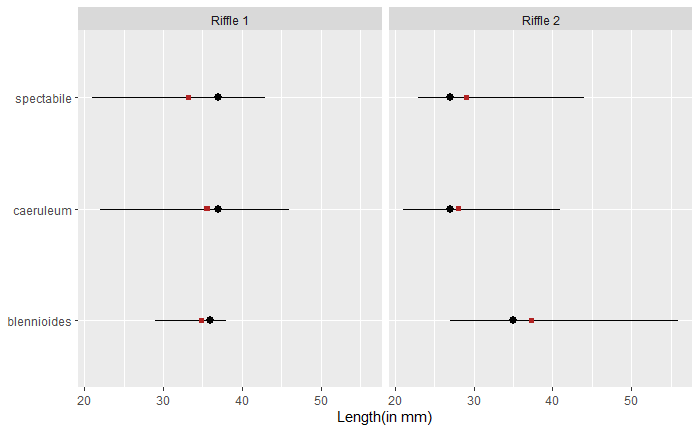

```r
ggplot(data = darter_summary_data) +
  stat_summary(mapping = aes(x = species, y = length),
               fun.ymin = min,
               fun.ymax = max,
               fun.y = median) +
  geom_point(data = darter_summary, mapping = aes(x = species, y = mean_length),
             shape = 15,
             color = 'firebrick') +
  coord_flip() +
  facet_wrap(~riffle) +
  labs(y ="Length(in mm)", x = NULL)
```

#This code chunk creates a summary graph for the darter_summary from above. This shows the median, minimum, and maximum data points for each of the species. The mean+length is also shown as the colored square in red on each of the lines. A facet_wrap is also applied that separates the graph by the two riffles. The values are coord_flipped to better space out the names of the species. The y is relabeled from length to "Length (in mm).

# Riffle 1 did not have the mean length appear for blennioides, this was because NA values were not removed.

Looking at each of the species we can see some large differences between the riffles. For the spectabile group, it has a very close minimum and maximum between riffles, but its median and mean are much higher in riffle 1 than riffle 2.

The Caeruleum species is very similar, but the riffle 1 has a higher maximum of ~46, compraed to riffle 2’s ~41. The mean for riffle 1 is also around ~36, compared to riffle 2’s ~28.

The blennioides had very similar median, minimum, and mean, but riffle 2 had a much larger maximum at ~56, compared to riffle 1’s ~38.